# Patron Frequency Plot

2022-11-03

There are 214418 unique words in the data set across all three time periods.

We’ll now take the top 1000, 100, and 50 most frequently used terms from each time frame that are 4 characters or longer. We’ll then plot the frequency of these words if, and only if, they occur in all three time periods.

Working with the 1000 most frequently used terms, there are 1135 unique terms in total, of which 871 are in all three time periods, and 264 are in only 1 or 2 of the time separated data sets.

- Blue = pre-pandemic
- Red = main-pandemic
- green = late pandemic

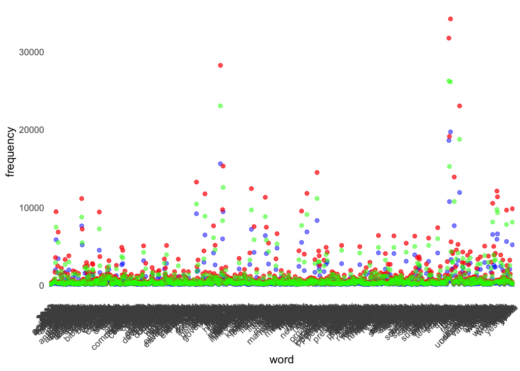

Working with the 100 most frequently used terms, there are 109 unique terms in total, of which 92 are in all three time periods, and 17 are in only 1 or 2 of the time separated data sets.

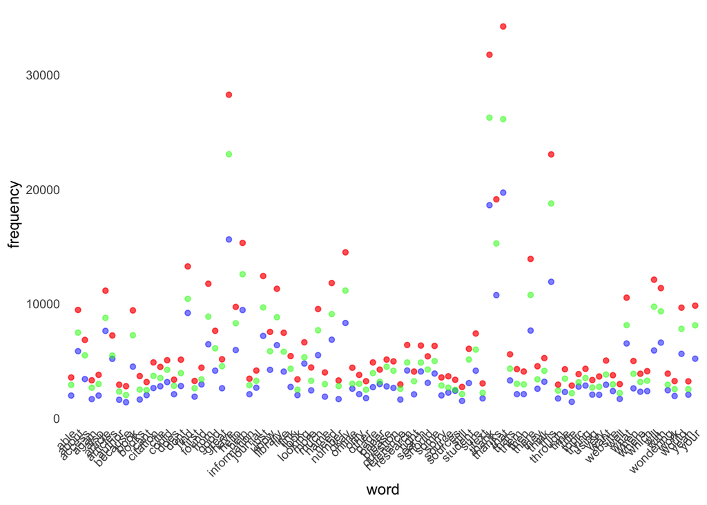

Working with the 50 most frequently used terms, there are 56 unique terms in total, of which 45 are in all three time periods, and 11 are in only 1 or 2 of the time separated data sets.

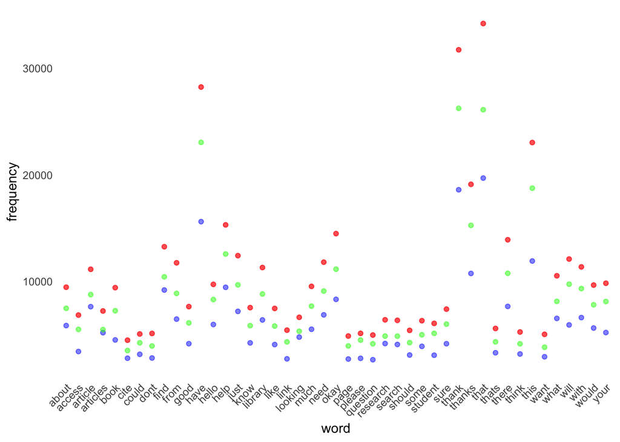